# Coursework Report

*N* removed NAs: 2

*N* removed typo: 1

*N* removed <18: 19

*N* total clean: 128

| Group | *N* | *M*<sub>age</sub> | *M*<sub>rating</sub> |
| --- | --- | --- | --- |
| Control | 65 | 20.1 | 5.92 |
| Experim | 63 | 20.8 | 6.97 |

**Main analysis results**

*t*(126) = -7.95, *p* < .001

[interactive chart not shown]

[figure not shown]

[interactive chart not shown]

# Coursework Report

Analysing Data, Spring 2020

# Methods

## Participants

*Table 1. Descriptive statistics by condition*

| Condition | N | % | M<sub>age</sub> | SD<sub>age</sub> |
| --- | --- | --- | --- | --- |
| Control | 65 | 50.8 | 20.1 | 1.7 |
| Experimental | 63 | 49.2 | 20.8 | 1.9 |

## Design

The conceptual hypothesis of the study is “Does colour influence attractiveness?”

Participants were randomly allocated to one of two conditions. In the control condition, participants were shown a black and white photo of a moderately attractive man on a white background. In the experimental condition, participants were shown the same photo of the man but on a red background. Using a Likert scale from 1-9, where 1 is not at all attractive and 9 is extremely attractive, participants were then asked to complete the following 3 rating scales about the perceived attractiveness of the man: “How attractive do you think this person is?”, “How pleasant is this person to look at?” and “If I were to meet the person in this picture face to face, I would think he is attractive.” High scores suggest that participants think the man is very attractive, and low scores suggest that participants do not think the man is attractive.

Will the perceived attractiveness (on a scale of 1-9) of a black and white photo of a moderately attractive man differ depending on whether the photo of the man is presented on a red or a white background?

To analyse this question, a t-test will need to be conducted, the predictor being colour and the outcome being attraction. The test will then tell us whether the results are significant enough to reject the null hypothesis, which will ultimately help to answer the conceptual hypothesis.

# Results

As shown in the graph below, there is a difference between the mean attractiveness ratings in the control condition and the experimental condition. Participants in the experimental condition, gave higher mean ratings of attractiveness (M = 6.97, SD = 0.74) than the participants in the control condition (M = 5.92, SD = 0.74). This suggests that participants in the experimental condition found the man to be more attractive than did the participants in the control condition. From the t-test, I received a t-value of -7.95 which means that the difference between the sample means of 1.05 was 7.95 times greater than the standard error of the difference in means. The probability of getting a value of that magnitude if the true difference in means is 0, is very unlikely (p <.001). Therefore, it is very unlikely that the two sample means come from the same population.

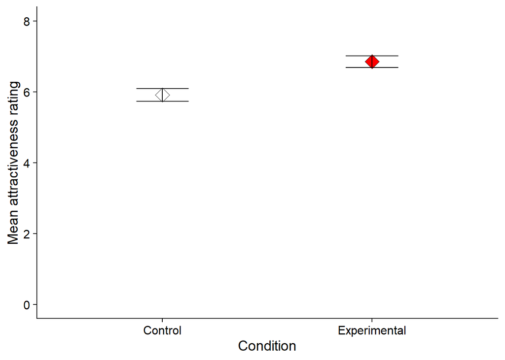

# Discussion

This research focused on replicating the study already conducted by Elliot et al (2010), to compare our findings and gain more insight and evidence into whether colour really does have an effect on attractiveness. Our results were similar to those of Elliot et al’s 7 experiments and Roberts et al’s experiment (2010) who also conducted the same study, in that women find men to be more attractive when associated with the colour red. Re et al (2011) conducted a similar study, where instead of presenting a photo of a man on either a white or a red background, they presented photos of both men and women’s faces before and after a photoshopped red enhancement. It was found that participants found the photoshopped faces with a red enhancement more attractive, which provides further evidence that colour has an effect on attractiveness.

Francis (2010) accused Elliot et al of publication bias as it was unlikely that all 7 of the experiments they conducted rejected the null hypothesis: that colour doesn’t have an effect on attractiveness. Francis stated, “Either some experiments with null findings were not reported or the reported experiments were run improperly”. This claim was backed up by the limited power of Elliot et al’s study and small sample sizes. Future research replicating Elliot et al’s study with bigger sample sizes may be able to tackle this problem. Having a big sample size will mean that the research will be a better representation of the true population mean, and therefore may be able to provide more power.

Hessingler, Goldback and Carbon (2015) also replicated Elliot et al’s study and found null results: red experimental condition (M = 5.71, SD = 1.70), white control condition (M = 5.39, SD = 1.53). This may suggest that Francis was right in pointing out that Elliot et al’s study has publication bias and may not be publishing null results. However, it could just mean that although colour in fact does effect attractiveness, Hessingler et al’s findings was an extreme result of the sampling distribution.

Research by Penton-Voak et al (1999) showed that women have different preferences in men at different points in their menstrual cycle. Women were shown to prefer softer feminine looking men at menstruation as they want to be cared for, and chiseled masculine looking men at ovulation when they are the most fertile, as this will ensure good genes will be passed onto their offspring. Future studies could research whether women are more attracted to men associated with different colours at different points of their menstrual cycle. For example, at menstruation women may prefer men associated with the colour pink and at ovulation women may prefer men associated with the colour red.

To conclude, many study findings support the hypothesis that colour affects attraction, but whether they are subject to publication bias or not, we don’t know. Publication bias is a big problem in the field of psychology due to the file drawer problem. If we were to ignore positive results as they may be subject to publication bias, then it would become impossible to conduct new research. Consequently, we can deduce that given the evidence, colour does affect attraction, but future research on the topic should include bigger sample sizes.

# References

Elliot, A. J., Niesta Kayser, D., Greitemeyer, T., Lichtenfeld, S., Gramzow, R. H., Maier, M. A., & Liu, H. (2010). Red, rank, and romance in women viewing men. Journal of Experimental Psychology: General, 139(3), 399.

Francis, G. (2013). Publication bias in “Red, rank, and romance in women viewing men,” by Elliot et al.(2010).

Hesslinger, V. M., Goldbach, L., & Carbon, C. C. (2015). Men in red: A reexamination of the red-attractiveness effect. Psychonomic bulletin & review, 22(4), 1142-1148.

Penton-Voak, I. S., Perrett, D. I., Castles, D. L., Kobayashi, T., Burt, D. M., Murray, L. K., & Minamisawa, R. (1999). Menstrual cycle alters face preference. Nature, 399(6738), 741-742.

Re, D. E., Whitehead, R. D., Xiao, D., & Perrett, D. I. (2011). Oxygenated-blood colour change thresholds for perceived facial redness, health, and attractiveness. PloS one, 6(3).

Roberts, S. C., Owen, R. C., & Havlicek, J. (2010). Distinguishing between perceiver and wearer effects in clothing color-associated attributions. Evolutionary Psychology, 8(3).